# Graphs (aggregate)

November 11, 2017

## Graphs (aggregate)

```
 [1] "annotate"   "Biobase"    "Biostrings" "caschrono"  "colorspace"
 [6] "copula"     "dplyr"      "ggplot2"    "grid"       "lmtest"
[11] "mvtnorm"    "rivr"       "stringr"    "tm"
```

## Overview

| package | functions | calls | promises | promise accesses | promise forces | promise lookups |
| --- | --- | --- | --- | --- | --- | --- |
| * | 15.8k | 15.2mln | 12.0mln | 13.9mln | 9.4mln | 4.5mln |
| dplyr | 1.4k | 1.7mln | 1.1mln | 1.3mln | 1.0mln | 341k |
| grid | 1.1k | 1.9mln | 1.6mln | 2.2mln | 1.0mln | 1.1mln |
| copula | 1.1k | 2.1mln | 1.5mln | 1.8mln | 1.3mln | 464k |
| annotate | 1.2k | 2.1mln | 1.8mln | 2.0mln | 1.4mln | 572k |
| colorspace | 1.6k | 2.2mln | 1.7mln | 1.9mln | 1.3mln | 660k |

**promise force** means the promise is accessed and the code of the promise is executed  
**promise lookup** mean the promise is accessed and the code of the promise is not executed

(showing top 5)

## Promise accesses (aggregate)

| classification | number | percentage |
| --- | --- | --- |
| accessed 1+ times, never forced | 99k | 0.82% |
| accessed 2+ times, forced 2+ times | 0 | 0.00% |
| accessed 2+ times, forced once | 1.8mln | 15.71% |
| accessed once, forced once | 7.5mln | 62.85% |
| never accessed | 2.4mln | 20.62% |

**promise force** means the promise is accessed and the code of the promise is executed  
**promise lookup** mean the promise is accessed and the code of the promise is not executed

## Promise accesses (separate)

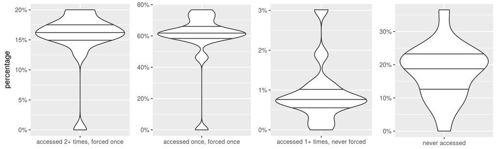

**promise force** means the promise is accessed and the code of the promise is executed  
**promise lookup** mean the promise is accessed and the code of the promise is not executed

## Number of accesses to a promise

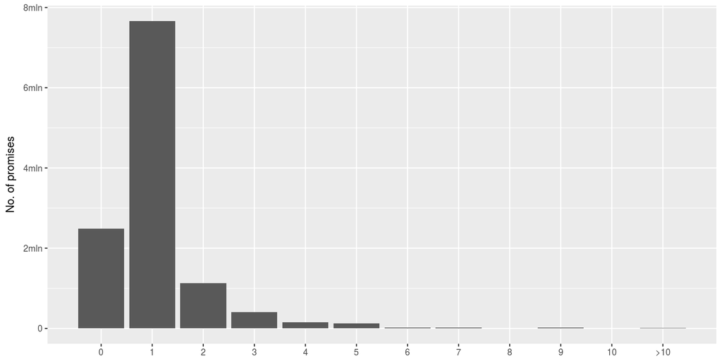

Promise types follow the type designations in `Rinternals.h`.

## Promise code types

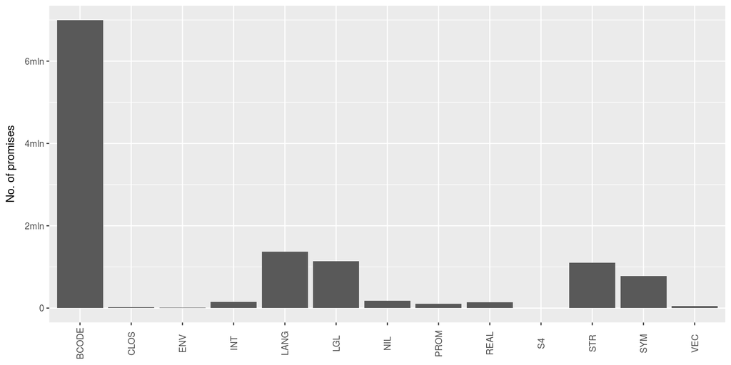

Promise types follow the type designations in `Rinternals.h`.

## What's inside promises?

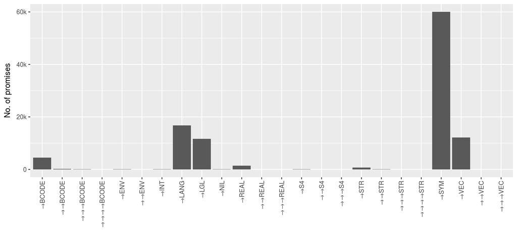

Promise types follow the type designations in `Rinternals.h`.  
**α** indicates that the promise contains the expression of type **α**.  
**→α** indicates that the promise contains a promise which contains the expression of type **α**, etc.

## What do promises return?

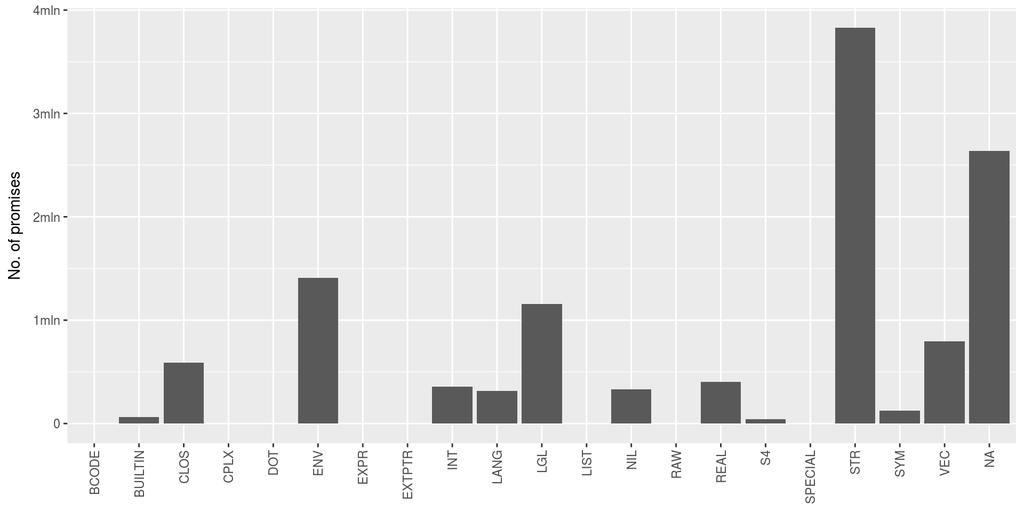

Promise types follow the type designations in `Rinternals.h`.

## What do specific promises return?

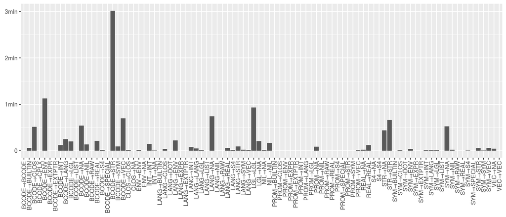

Promise types follow the type designations in `Rinternals.h`.  
**α→β** indicates that the promise contains an expression of type **α** which evaluates to an expression of type **β** when the promise is forced.

## Promise forces by types

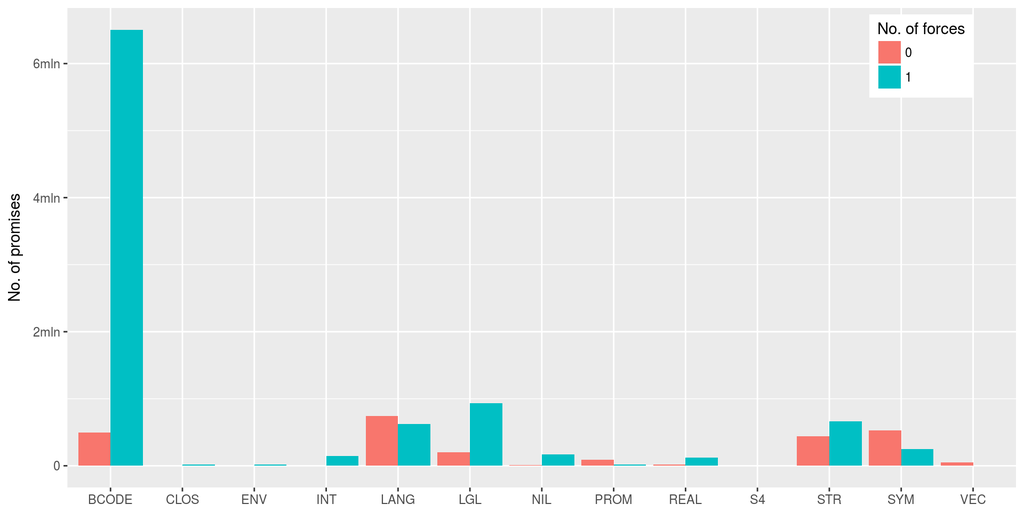

Promise types follow the type designations in `Rinternals.h`.

## Promise evaluation distances

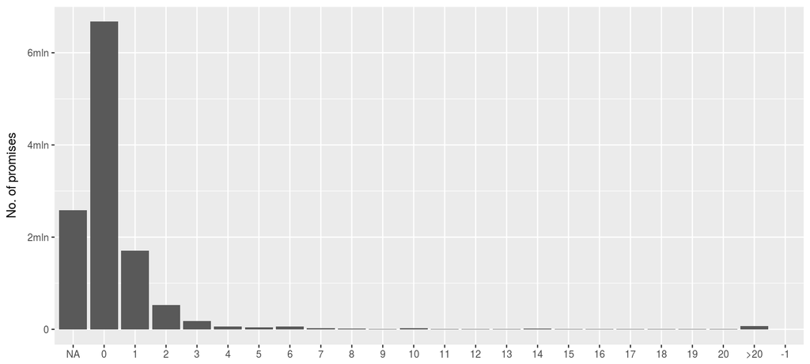

**n** - distance from the function for which a promise was created and the function in which it was evaluated  
**NA** - promise was not executed, there is no distance measure (a virgin promise)  
**-1** - promise was executed but there is no path from the origin to the point of evaluation (an escaped promise)

## Functions and calls by type

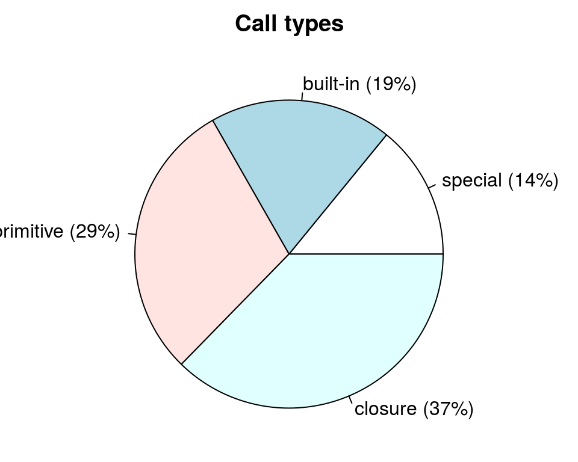

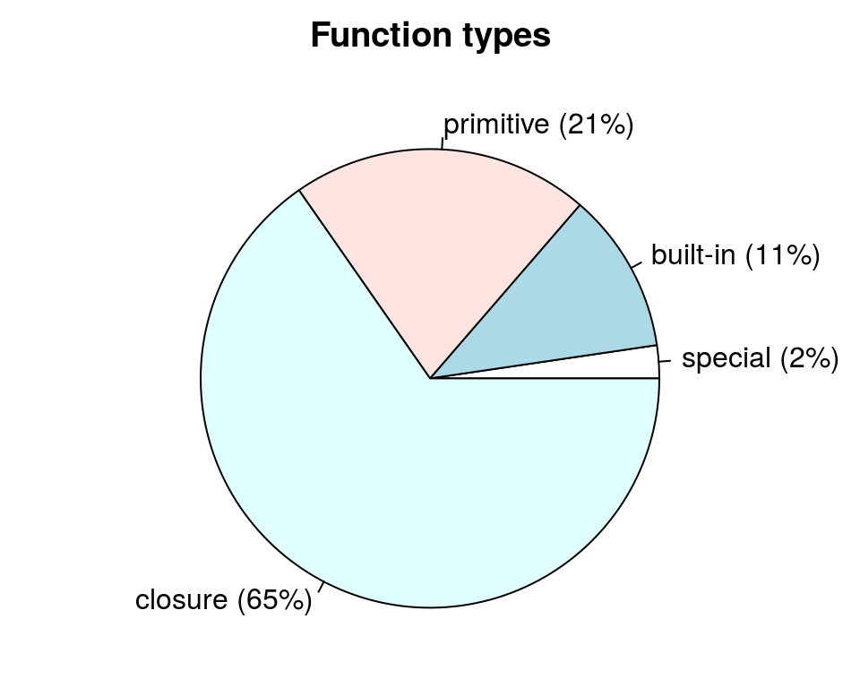

**functions** refers to function definitions  
**calls** refers to function executions/calls

## Byte-code compilation

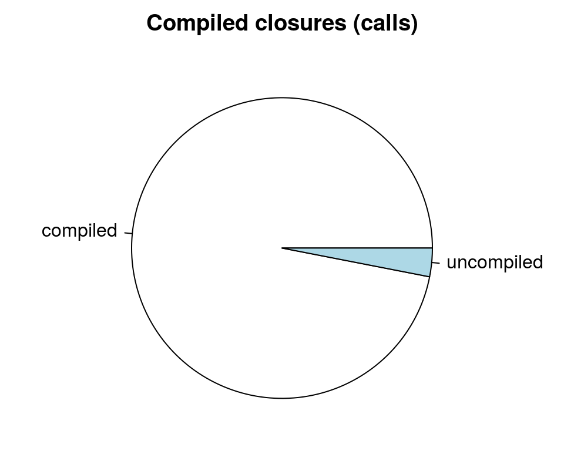

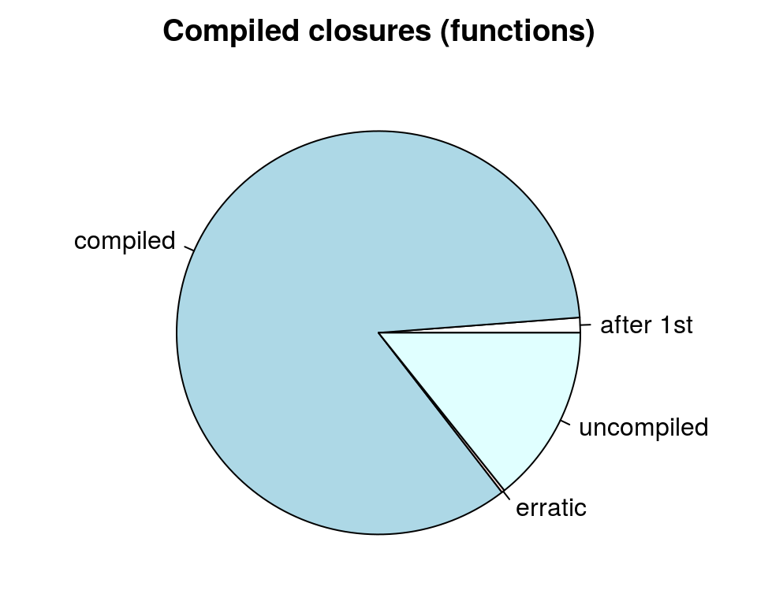

When calling a function it's either byte-code **compiled** or **uncompiled**. When agregated across all calls to a function, a function can be:  
**compiled** - all calls to this function are compiled,  
**uncompiled** - none of the calls to this function are compiled,  
**after 1st** - a function can be compiled by the JIT, so it can be uncompiled initially and then compiled later on,  
**erratic** - a function is sometimes compiled and sometimes not; it can indicate that two separate functions are indistinguishable to the tracer (same definition, unknown location) and one of them is compiled while another is not.

## Interactions among promises

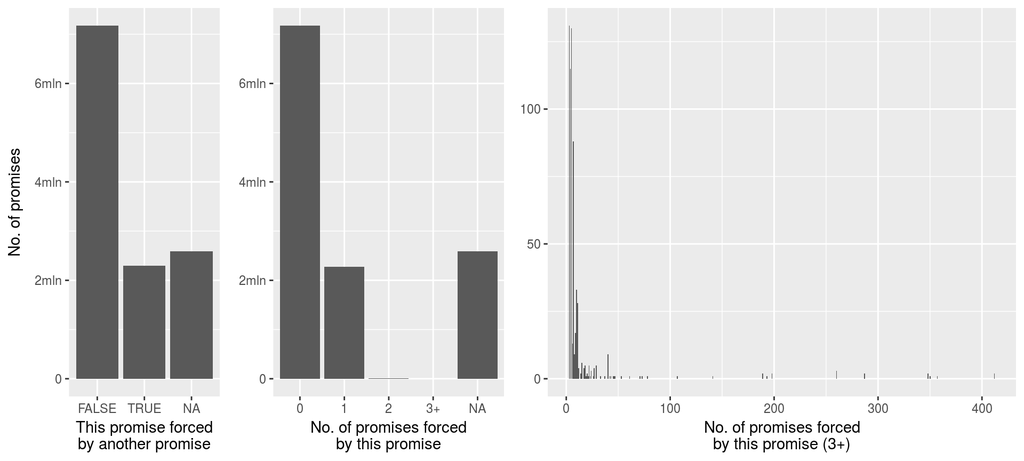

Promises forced by other promises:  
`TRUE` is when a promise was created within some promise x but was forced within a different promise y.  
`FALSE` is when a promise was forced within the same promise as it was created.  
`NA` means the promise was not forced.

## Strictness

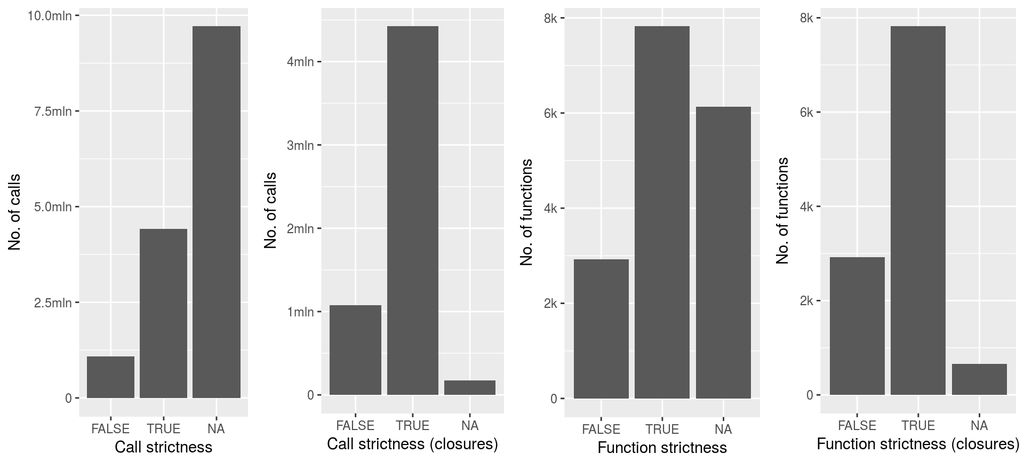

A call is **strict** if all of its arguments are **evaluated** and none of the arguments is **escaped**. (This means that a function may pass unevaluated promises to a child call and still be strict, but it cannot leak the promise).  
A function is **strict** if all of its calls are **strict**. Functions that don't take promises are neither **strict** nor **non-strict** – these can be either arrity-0 closures or built-in (which accept values rather than promises).

## Call strictness ratios (dominant)

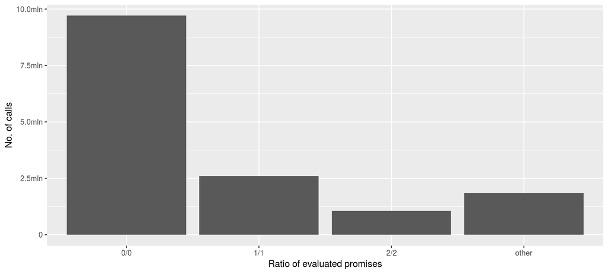

**Strictness ratio** of the form `n/m` means that a call evaluated `n` promises out of `m` promises that were created for it. `0/0` can mean either that a function had no arguments or that it was a built-in etc (had arguments, but they were passed without promises).

## Call strictness ratios (other top 20)

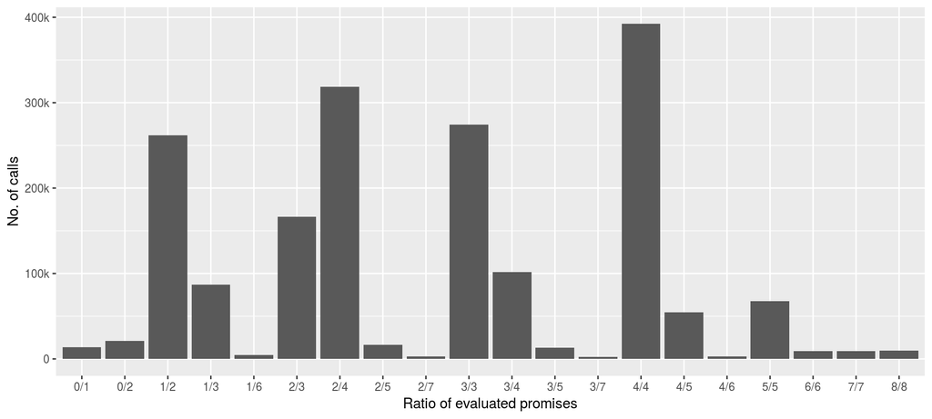

**Strictness ratio** of the form `n/m` means that a call evaluated `n` promises out of `m` promises that were created for it. `0/0` can mean either that a function had no arguments or that it was a built-in etc (had arguments, but they were passed without promises).

## Call strictness ratios (other)

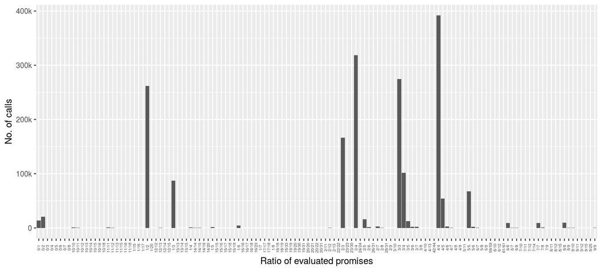

**Strictness ratio** of the form `n/m` means that a call evaluated `n` promises out of `m` promises that were created for it. `0/0` can mean either that a function had no arguments or that it was a built-in etc (had arguments, but they were passed without promises).

## Function strictness rate

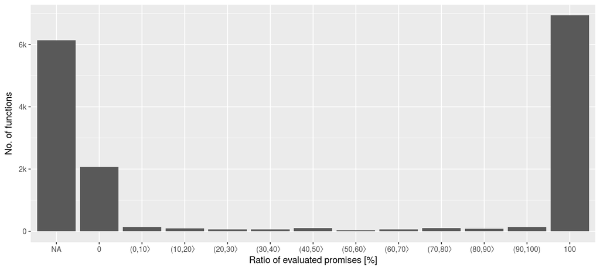

**Strictness rate** reflects what percentage of calls were strict.  
**NA** means the function had no argument.  
**(n,m〉** means the function had between n% and m% strict calls.

## Evaluation order

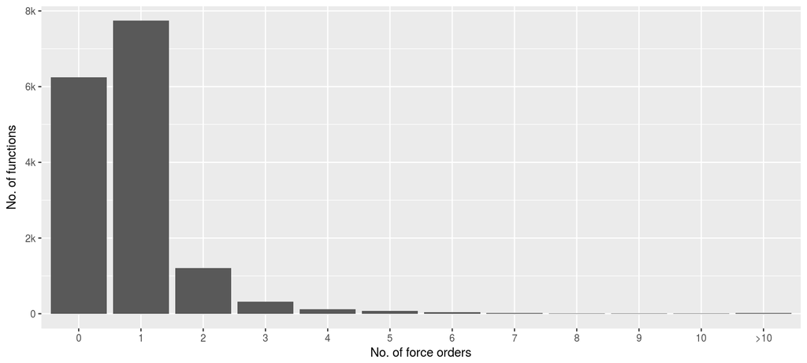

## Argument promise mode

How many argument promises are default and how many are not.

| RUNNABLE | ALL | DEFAULT.ARGUMENT | NON.DEFAULT.ARGUMENT | UNACCOUNTED | X..of.DEFAULT.ARGUMENTS | X..of.NON.DEFAULT.ARGUMENT. | X..UNACCOUNTED |
| --- | --- | --- | --- | --- | --- | --- | --- |
| dplyr-compatibility | 75803 | 16263 | 51246 | 8294 | 21.45% | 67.60% | 10.94% |
| dplyr-dplyr | 429436 | 100327 | 303486 | 25623 | 23.36% | 70.67% | 5.97% |
| dplyr-programming | 21374 | 4890 | 14857 | 1627 | 22.88% | 69.51% | 7.61% |
| dplyr-two-table | 213776 | 52766 | 156197 | 4813 | 24.68% | 73.07% | 2.25% |
| dplyr-window-functions | 396975 | 78681 | 310456 | 7838 | 19.82% | 78.21% | 1.97% |
| grid-displaylist | 7188 | 1165 | 5486 | 537 | 16.21% | 76.32% | 7.47% |
| grid-frame | 104297 | 16585 | 65579 | 22133 | 15.90% | 62.88% | 21.22% |
| grid-grid | 180542 | 27229 | 124387 | 28926 | 15.08% | 68.90% | 16.02% |
| grid-grobs | 168690 | 17258 | 99384 | 52048 | 10.23% | 58.92% | 30.85% |
| grid-interactive | 14488 | 1345 | 8824 | 4319 | 9.28% | 60.91% | 29.81% |
| grid-locndimn | 27558 | 4888 | 18243 | 4427 | 17.74% | 66.20% | 16.06% |
| grid-moveline | 31742 | 4695 | 21587 | 5460 | 14.79% | 68.01% | 17.20% |
| grid-nonfinite | 37713 | 6904 | 24850 | 5959 | 18.31% | 65.89% | 15.80% |
| grid-plotexample | 1143774 | 104079 | 635102 | 404593 | 9.10% | 55.53% | 35.37% |
| grid-rotated | 73190 | 8000 | 48956 | 16234 | 10.93% | 66.89% | 22.18% |
| grid-saveload | 1335 | 276 | 827 | 232 | 20.67% | 61.95% | 17.38% |
| grid-sharing | 33703 | 3332 | 20485 | 9886 | 9.89% | 60.78% | 29.33% |
| grid-viewports | 50543 | 5847 | 32832 | 11864 | 11.57% | 64.96% | 23.47% |
| rivr-publication-reproduction | 4913 | 1138 | 3256 | 519 | 23.16% | 66.27% | 10.56% |
| rivr-quickstart | 201260 | 45086 | 133919 | 22255 | 22.40% | 66.54% | 11.06% |
| rivr-technical-vignette | 17 | 5 | 12 | 0 | 29.41% | 70.59% | 0.00% |
| stringr-regular-expressions | 1643 | 742 | 871 | 30 | 45.16% | 53.01% | 1.83% |
| stringr-stringr | 35680 | 7488 | 23354 | 4838 | 20.99% | 65.45% | 13.56% |
| vcd-residual-shadings | 1728463 | 185588 | 1347473 | 195402 | 10.74% | 77.96% | 11.30% |
| vcd-strucplot | 5591921 | 821115 | 3619415 | 1151391 | 14.68% | 64.73% | 20.59% |

https://docs.google.com/spreadsheets/d/1miVXUxCoeYiBR0eiCB3Ipa3KBCDw7OZ77qy7RJHFJ_8/edit#gid=333058396

## Argument position laziness (top 20)

At each argument position, how often is the argument evaluated and how often it is not.

[output not shown]

https://docs.google.com/spreadsheets/d/1Fb9JdbTMXqoX-xJqhxH063ZQjL9wE5ghO12y63TxyOs/edit#gid=0

## Environment access

How often, environment functions are used to access, create or modify existing environments

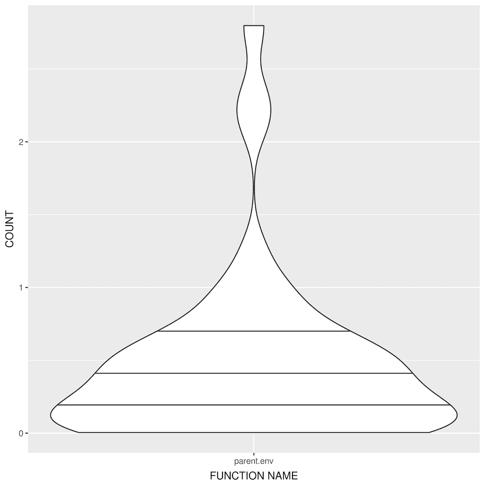

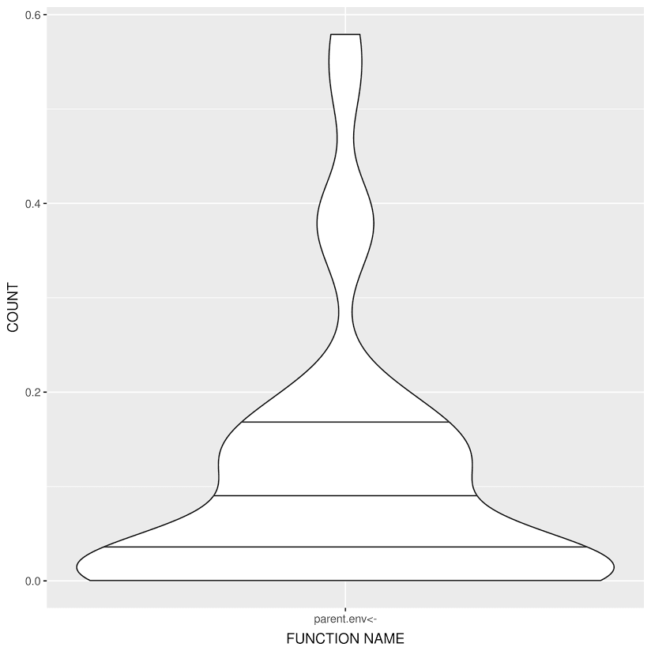

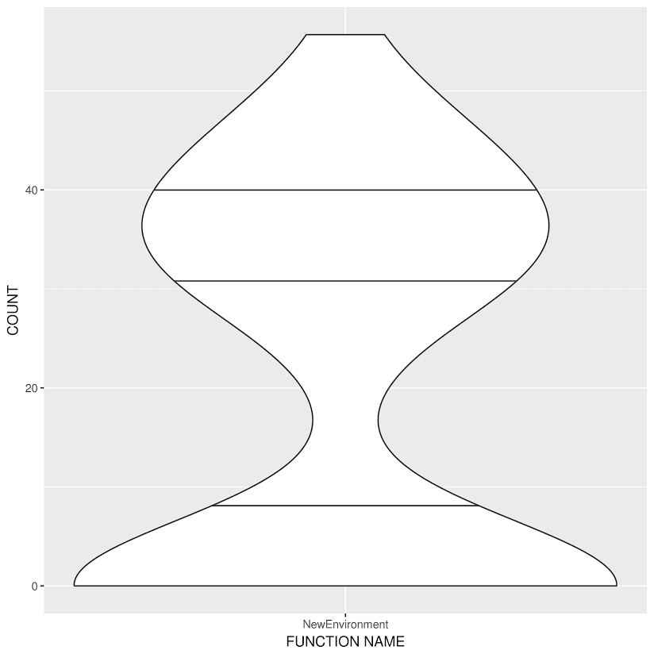

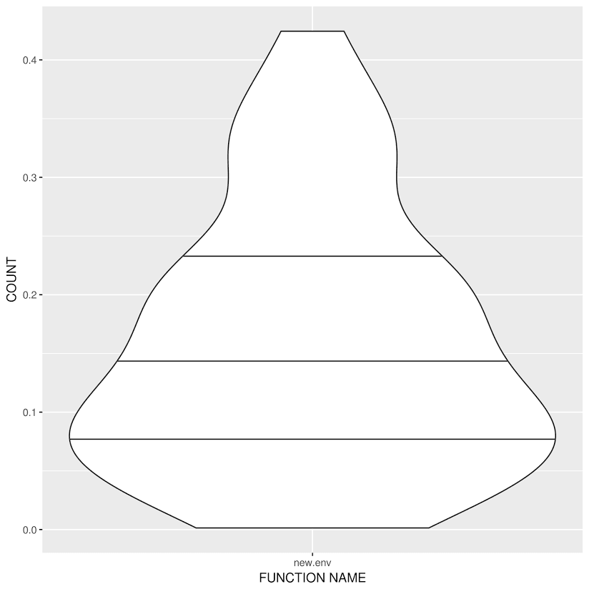

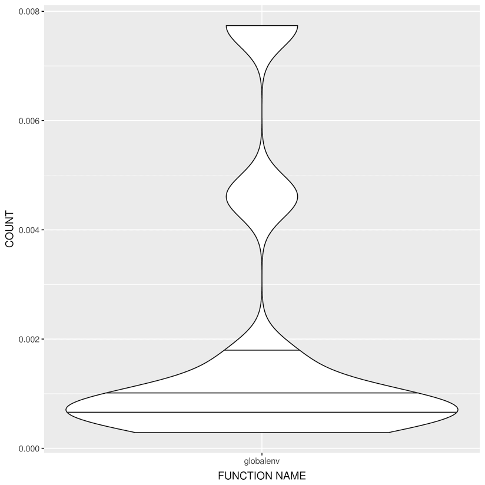

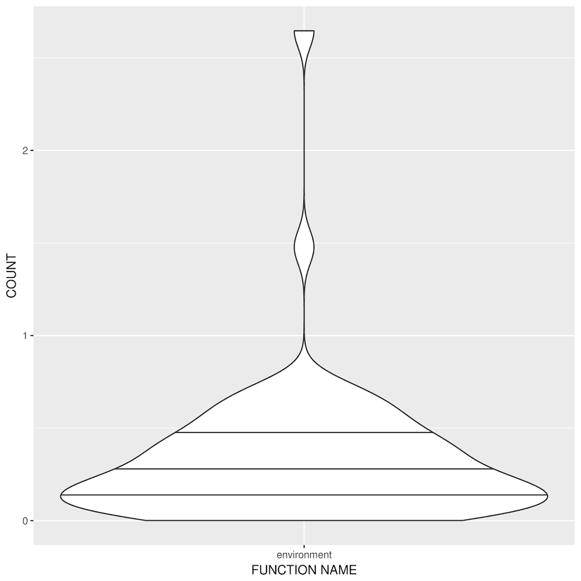

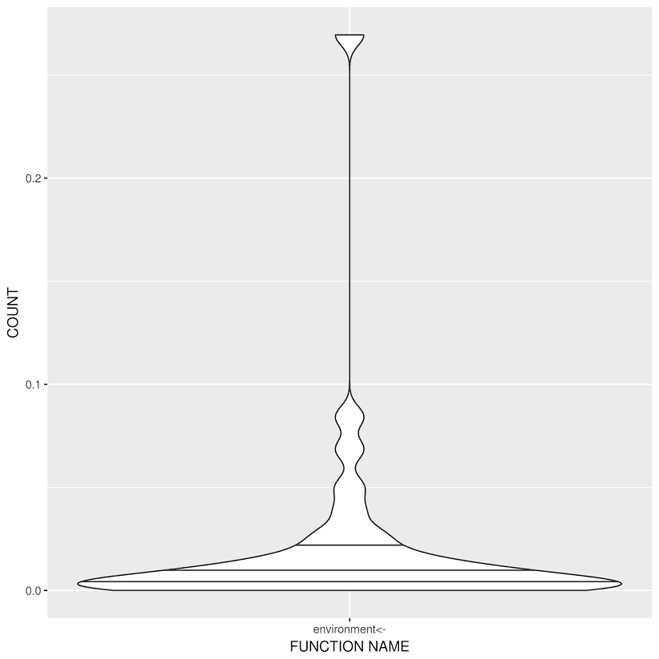

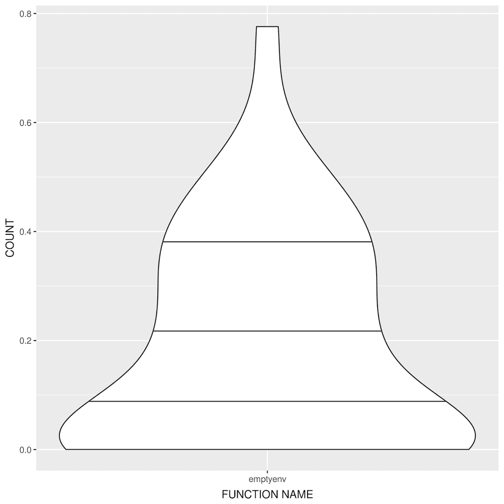

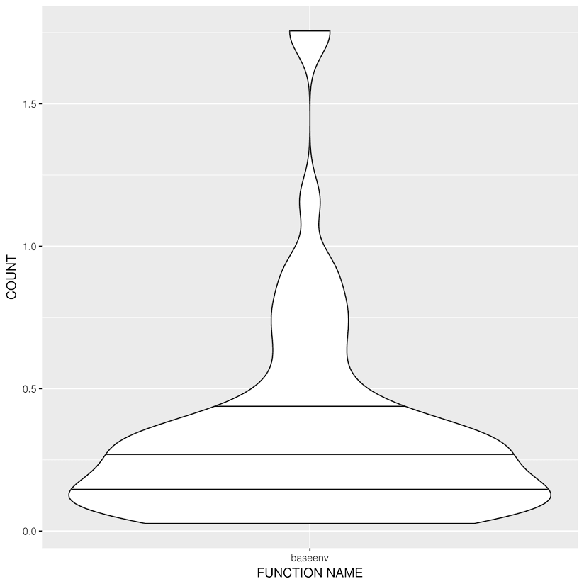

https://docs.google.com/spreadsheets/d/1nwoPDs2gdipw0vtHqhfFWv4cwGQrp5b7qAbUjqsf4pc/edit#gid=177224429

## Default and non-default promise arguments

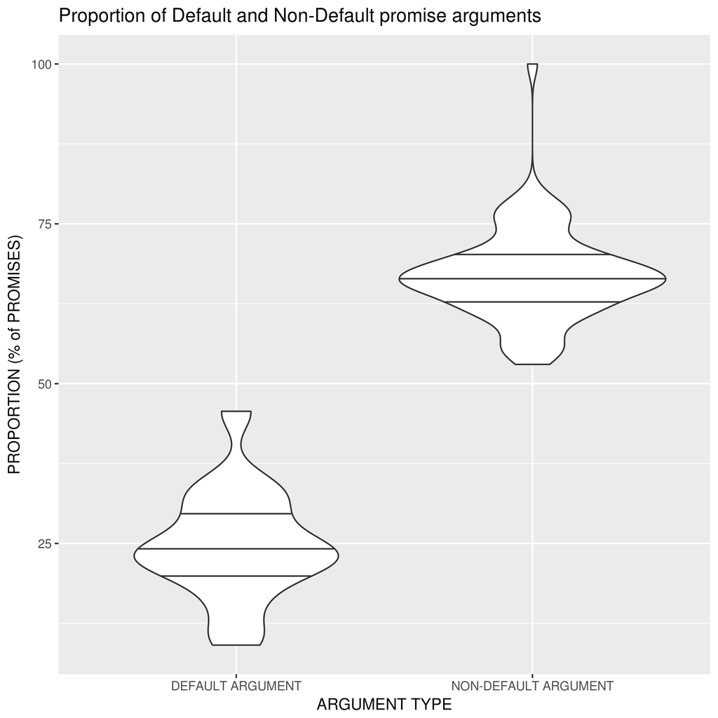

## Calls to specific functions

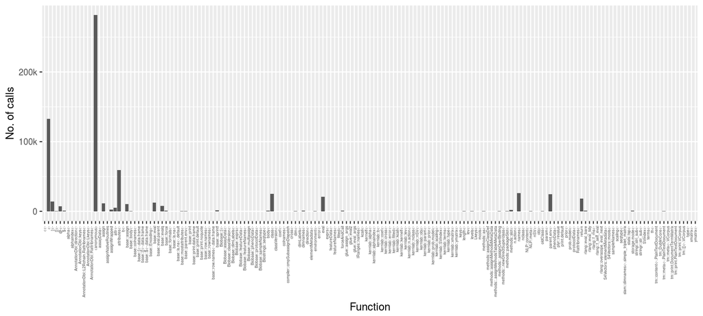